# Basic Classification - Case

## Problem

FarmX collaborates with another company, Seeder, to provide farmers with seeds to grow. The seeds that they receive from Seeder are all for the same plant, but have different properties based on what environment they will be grown in as FarmX's farmers are very spread out and in locations with different climates. There are three classes total.

For quality control, FarmX wants to make sure they can verify themselves what class a seed is in. They decide to collect measurements on a number of seeds and compile the results.

LionBase has been asked to build a predictive model for seed type.

## Step 1: Import Modules

```python
import numpy as np
import pandas as pd
import matplotlib.pyplot as plt
from matplotlib import colors
from sklearn.model_selection import cross_validate
from sklearn.model_selection import train_test_split
from sklearn.preprocessing import StandardScaler
from sklearn.metrics import accuracy_score
from sklearn.discriminant_analysis import LinearDiscriminantAnalysis as LDA
from sklearn.linear_model import LogisticRegression
from sklearn.neighbors import KNeighborsClassifier
from sklearn import preprocessing
%matplotlib inline
```

## Step 2: Read in Data

```python
df = pd.read_csv('data/seeds_dataset.txt',sep='\t',header=None) # read in data
```

```python
df.columns = ['Area', 'Perimeter', 'Compactness',
              'Length of kernel', 'Width of kernel', 'Asymmetry coefficient',
             'Length of kernel groove', 'Class'] # set column names, provided by client
```

```python
df.head() # preview data
```

|  | Area | Perimeter | Compactness | Length of kernel | Width of kernel | Asymmetry coefficient | Length of kernel groove | Class |
| --- | --- | --- | --- | --- | --- | --- | --- | --- |
| 0 | 15.26 | 14.84 | 0.8710 | 5.763 | 3.312 | 2.221 | 5.220 | 1 |
| 1 | 14.88 | 14.57 | 0.8811 | 5.554 | 3.333 | 1.018 | 4.956 | 1 |
| 2 | 14.29 | 14.09 | 0.9050 | 5.291 | 3.337 | 2.699 | 4.825 | 1 |
| 3 | 13.84 | 13.94 | 0.8955 | 5.324 | 3.379 | 2.259 | 4.805 | 1 |
| 4 | 16.14 | 14.99 | 0.9034 | 5.658 | 3.562 | 1.355 | 5.175 | 1 |

```python
df['Class'].value_counts() # check class balance
```

```
3    70
2    70
1    70
Name: Class, dtype: int64
```

Classes are balanced! And we know that there are three classes.

## Implement Linear Discriminant Analysis

### Step 1: Sort Classes

```python
df = df.sort_values(by=['Class']) # sort in ascending order of class
```

```python
df
```

|  | Area | Perimeter | Compactness | Length of kernel | Width of kernel | Asymmetry coefficient | Length of kernel groove | Class |
| --- | --- | --- | --- | --- | --- | --- | --- | --- |
| 0 | 15.26 | 14.84 | 0.8710 | 5.763 | 3.312 | 2.221 | 5.220 | 1 |
| 50 | 14.43 | 14.40 | 0.8751 | 5.585 | 3.272 | 3.975 | 5.144 | 1 |
| 49 | 14.86 | 14.67 | 0.8676 | 5.678 | 3.258 | 2.129 | 5.351 | 1 |
| 48 | 14.79 | 14.52 | 0.8819 | 5.545 | 3.291 | 2.704 | 5.111 | 1 |
| 47 | 14.99 | 14.56 | 0.8883 | 5.570 | 3.377 | 2.958 | 5.175 | 1 |
| 46 | 15.36 | 14.76 | 0.8861 | 5.701 | 3.393 | 1.367 | 5.132 | 1 |
| 45 | 13.80 | 14.04 | 0.8794 | 5.376 | 3.155 | 1.560 | 4.961 | 1 |
| 51 | 15.78 | 14.91 | 0.8923 | 5.674 | 3.434 | 5.593 | 5.136 | 1 |
| 44 | 15.11 | 14.54 | 0.8986 | 5.579 | 3.462 | 3.128 | 5.180 | 1 |
| 42 | 13.16 | 13.55 | 0.9009 | 5.138 | 3.201 | 2.461 | 4.783 | 1 |
| 41 | 13.50 | 13.85 | 0.8852 | 5.351 | 3.158 | 2.249 | 5.176 | 1 |
| 40 | 13.54 | 13.85 | 0.8871 | 5.348 | 3.156 | 2.587 | 5.178 | 1 |
| 39 | 14.28 | 14.17 | 0.8944 | 5.397 | 3.298 | 6.685 | 5.001 | 1 |
| 38 | 14.80 | 14.52 | 0.8823 | 5.656 | 3.288 | 3.112 | 5.309 | 1 |
| 37 | 17.08 | 15.38 | 0.9079 | 5.832 | 3.683 | 2.956 | 5.484 | 1 |
| 43 | 15.50 | 14.86 | 0.8820 | 5.877 | 3.396 | 4.711 | 5.528 | 1 |
| 36 | 16.20 | 15.27 | 0.8734 | 5.826 | 3.464 | 2.823 | 5.527 | 1 |
| 53 | 14.33 | 14.28 | 0.8831 | 5.504 | 3.199 | 3.328 | 5.224 | 1 |
| 55 | 15.03 | 14.77 | 0.8658 | 5.702 | 3.212 | 1.933 | 5.439 | 1 |
| 69 | 12.73 | 13.75 | 0.8458 | 5.412 | 2.882 | 3.533 | 5.067 | 1 |
| 68 | 14.37 | 14.39 | 0.8726 | 5.569 | 3.153 | 1.464 | 5.300 | 1 |
| 67 | 14.01 | 14.29 | 0.8625 | 5.609 | 3.158 | 2.217 | 5.132 | 1 |
| 66 | 14.34 | 14.37 | 0.8726 | 5.630 | 3.190 | 1.313 | 5.150 | 1 |
| 65 | 12.88 | 13.50 | 0.8879 | 5.139 | 3.119 | 2.352 | 4.607 | 1 |
| 64 | 12.78 | 13.57 | 0.8716 | 5.262 | 3.026 | 1.176 | 4.782 | 1 |
| 54 | 14.52 | 14.60 | 0.8557 | 5.741 | 3.113 | 1.481 | 5.487 | 1 |
| 63 | 13.22 | 13.84 | 0.8680 | 5.395 | 3.070 | 4.157 | 5.088 | 1 |
| 61 | 11.23 | 12.63 | 0.8840 | 4.902 | 2.879 | 2.269 | 4.703 | 1 |
| 60 | 11.42 | 12.86 | 0.8683 | 5.008 | 2.850 | 2.700 | 4.607 | 1 |
| 59 | 12.11 | 13.47 | 0.8392 | 5.159 | 3.032 | 1.502 | 4.519 | 1 |
| ... | ... | ... | ... | ... | ... | ... | ... | ... |
| 149 | 10.79 | 12.93 | 0.8107 | 5.317 | 2.648 | 5.462 | 5.194 | 3 |
| 148 | 12.70 | 13.71 | 0.8491 | 5.386 | 2.911 | 3.260 | 5.316 | 3 |
| 154 | 11.36 | 13.05 | 0.8382 | 5.175 | 2.755 | 4.048 | 5.263 | 3 |
| 147 | 12.49 | 13.46 | 0.8658 | 5.267 | 2.967 | 4.421 | 5.002 | 3 |
| 145 | 11.21 | 13.13 | 0.8167 | 5.279 | 2.687 | 6.169 | 5.275 | 3 |
| 144 | 11.82 | 13.40 | 0.8274 | 5.314 | 2.777 | 4.471 | 5.178 | 3 |
| 143 | 12.22 | 13.32 | 0.8652 | 5.224 | 2.967 | 5.469 | 5.221 | 3 |
| 142 | 13.34 | 13.95 | 0.8620 | 5.389 | 3.074 | 5.995 | 5.307 | 3 |
| 141 | 13.32 | 13.94 | 0.8613 | 5.541 | 3.073 | 7.035 | 5.440 | 3 |
| 140 | 13.07 | 13.92 | 0.8480 | 5.472 | 2.994 | 5.304 | 5.395 | 3 |
| 146 | 11.43 | 13.13 | 0.8335 | 5.176 | 2.719 | 2.221 | 5.132 | 3 |
| 173 | 11.40 | 13.08 | 0.8375 | 5.136 | 2.763 | 5.588 | 5.089 | 3 |
| 155 | 11.19 | 13.05 | 0.8253 | 5.250 | 2.675 | 5.813 | 5.219 | 3 |
| 208 | 11.84 | 13.21 | 0.8521 | 5.175 | 2.836 | 3.598 | 5.044 | 3 |
| 171 | 11.55 | 13.10 | 0.8455 | 5.167 | 2.845 | 6.715 | 4.956 | 3 |
| 170 | 11.02 | 13.00 | 0.8189 | 5.325 | 2.701 | 6.735 | 5.163 | 3 |
| 169 | 11.24 | 13.00 | 0.8359 | 5.090 | 2.715 | 3.521 | 5.088 | 3 |
| 168 | 11.35 | 13.12 | 0.8291 | 5.176 | 2.668 | 4.337 | 5.132 | 3 |
| 167 | 12.15 | 13.45 | 0.8443 | 5.417 | 2.837 | 3.638 | 5.338 | 3 |
| 166 | 12.44 | 13.59 | 0.8462 | 5.319 | 2.897 | 4.924 | 5.270 | 3 |
| 156 | 11.34 | 12.87 | 0.8596 | 5.053 | 2.849 | 3.347 | 5.003 | 3 |
| 165 | 12.10 | 13.15 | 0.8793 | 5.105 | 2.941 | 2.201 | 5.056 | 3 |
| 163 | 12.55 | 13.57 | 0.8558 | 5.333 | 2.968 | 4.419 | 5.176 | 3 |
| 162 | 12.05 | 13.41 | 0.8416 | 5.267 | 2.847 | 4.988 | 5.046 | 3 |
| 161 | 12.02 | 13.33 | 0.8503 | 5.350 | 2.810 | 4.271 | 5.308 | 3 |
| 160 | 12.54 | 13.67 | 0.8425 | 5.451 | 2.879 | 3.082 | 5.491 | 3 |
| 159 | 11.49 | 13.22 | 0.8263 | 5.304 | 2.695 | 5.388 | 5.310 | 3 |
| 158 | 11.75 | 13.52 | 0.8082 | 5.444 | 2.678 | 4.378 | 5.310 | 3 |
| 164 | 11.14 | 12.79 | 0.8558 | 5.011 | 2.794 | 6.388 | 5.049 | 3 |
| 209 | 12.30 | 13.34 | 0.8684 | 5.243 | 2.974 | 5.637 | 5.063 | 3 |

210 rows × 8 columns

This will help us color code the results later.

### Step 2: Create Features and Dependent Variable

```python
X = df.iloc[:,0:7].values # get feature set
X
```

```
array([[ 15.26  ,  14.84  ,   0.871 , ...,   3.312 ,   2.221 ,   5.22  ],
       [ 14.43  ,  14.4   ,   0.8751, ...,   3.272 ,   3.975 ,   5.144 ],
       [ 14.86  ,  14.67  ,   0.8676, ...,   3.258 ,   2.129 ,   5.351 ],
       ...,
       [ 11.75  ,  13.52  ,   0.8082, ...,   2.678 ,   4.378 ,   5.31  ],
       [ 11.14  ,  12.79  ,   0.8558, ...,   2.794 ,   6.388 ,   5.049 ],
       [ 12.3   ,  13.34  ,   0.8684, ...,   2.974 ,   5.637 ,   5.063 ]])
```

```python
y = df.iloc[:,7].values # get last column as dependent variable
y
```

```
array([1, 1, 1, 1, 1, 1, 1, 1, 1, 1, 1, 1, 1, 1, 1, 1, 1, 1, 1, 1, 1, 1, 1,
       1, 1, 1, 1, 1, 1, 1, 1, 1, 1, 1, 1, 1, 1, 1, 1, 1, 1, 1, 1, 1, 1, 1,
       1, 1, 1, 1, 1, 1, 1, 1, 1, 1, 1, 1, 1, 1, 1, 1, 1, 1, 1, 1, 1, 1, 1,
       1, 2, 2, 2, 2, 2, 2, 2, 2, 2, 2, 2, 2, 2, 2, 2, 2, 2, 2, 2, 2, 2, 2,
       2, 2, 2, 2, 2, 2, 2, 2, 2, 2, 2, 2, 2, 2, 2, 2, 2, 2, 2, 2, 2, 2, 2,
       2, 2, 2, 2, 2, 2, 2, 2, 2, 2, 2, 2, 2, 2, 2, 2, 2, 2, 2, 2, 2, 2, 2,
       2, 2, 3, 3, 3, 3, 3, 3, 3, 3, 3, 3, 3, 3, 3, 3, 3, 3, 3, 3, 3, 3, 3,
       3, 3, 3, 3, 3, 3, 3, 3, 3, 3, 3, 3, 3, 3, 3, 3, 3, 3, 3, 3, 3, 3, 3,
       3, 3, 3, 3, 3, 3, 3, 3, 3, 3, 3, 3, 3, 3, 3, 3, 3, 3, 3, 3, 3, 3, 3,
       3, 3, 3])
```

### Step 3: Create LDA Model

```python
lda = LDA() # create LDA model
lda.fit(X,y) # fit LDA model
X_transformed = lda.transform(X) #transform X
```

```python
df_transformed = pd.DataFrame.from_records(X_transformed)
df_transformed.head()
```

|  | 0 | 1 |
| --- | --- | --- |
| 0 | -0.431322 | -3.447686 |
| 1 | -0.978500 | -2.140553 |
| 2 | -0.008221 | -1.880883 |
| 3 | -0.440257 | -2.552090 |
| 4 | -0.293511 | -2.220215 |

### Step 4: Visualize Result

```python
class1 = df_transformed.iloc[0:70] # since the first 70 rows are class 1 after sorting
```

```python
class2 = df_transformed.iloc[70:140] # since the next 70 rows are class 2 after sorting
```

```python
class3 = df_transformed.iloc[140:] # since the last 70 rows are class 3 after sorting
```

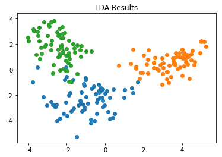

```python
plt.title('LDA Results')
plt.scatter(class1[0], class1[1])
plt.scatter(class2[0], class2[1])
plt.scatter(class3[0], class3[1])
```

**Analyze Results**

- There are three relatively distinct clusters, so the LDA did a good job classifying each group

However, this was done using the entire dataset as training data so it may be overfit. Let's try a 5-fold cross-validation.

### Step 5: 5-Fold Cross-Validation

```python
lda = LDA()
cv_results= cross_validate(lda, X,y,cv=5)
print('LDA Results: ')
print(cv_results['test_score'])
```

```
LDA Results:
[ 1.          0.92857143  0.92857143  0.97619048  0.97619048]
```

```python
print('Average Accuracy: {}'.format(cv_results['test_score'].mean()))
```

```
Average Accuracy: 0.9619047619047618
```

Overall, LDA does a good and consistent job of classifying the seeds!

## Implement kNN

### Step 1: Create Training and Test Sets

```python
X_train, X_test, y_train, y_test = train_test_split(X, y, test_size=0.25, random_state=42)
```

### Step 2: Create Initial kNN Model

```python
model = KNeighborsClassifier(n_neighbors=3)

# Train the model using the training sets
model.fit(X_train,y_train)

predicted= model.predict(X_test)
print(predicted)
```

```
[1 1 2 3 1 3 1 3 1 3 2 3 3 2 2 2 3 1 3 1 2 1 3 2 2 3 1 2 2 3 3 1 2 1 2 2 3
 2 2 3 3 3 1 2 3 1 1 2 2 1 1 3 2]
```

```python
acc = accuracy_score(y_true=y_test, y_pred=predicted)
print(acc)
```

```
0.88679245283
```

**Analyze Results**

- Good accuracy, but not as good as LDA
- However, we have not fine-tuned for the number of neighbors nearby -- let's test out different n_neighbor parameters

### Step 3: Test Out Differnt kNNs

```python
for n in range(20):
    model = KNeighborsClassifier(n_neighbors=n+1) # increment up number of neighbors one by one
    model.fit(X_train, y_train)
    predicted = model.predict(X_test)
    acc = accuracy_score(y_true=y_test, y_pred=predicted)
    print('{}-NN Accuracy: {}'.format(n+1,acc))
```

```
1-NN Accuracy: 0.8679245283018868
2-NN Accuracy: 0.8867924528301887
3-NN Accuracy: 0.8867924528301887
4-NN Accuracy: 0.9245283018867925
5-NN Accuracy: 0.8867924528301887
6-NN Accuracy: 0.8867924528301887
7-NN Accuracy: 0.8867924528301887
8-NN Accuracy: 0.9056603773584906
9-NN Accuracy: 0.9056603773584906
10-NN Accuracy: 0.9056603773584906
11-NN Accuracy: 0.9056603773584906
12-NN Accuracy: 0.9056603773584906
13-NN Accuracy: 0.9056603773584906
14-NN Accuracy: 0.8867924528301887
15-NN Accuracy: 0.8867924528301887
16-NN Accuracy: 0.9056603773584906
17-NN Accuracy: 0.8867924528301887
18-NN Accuracy: 0.9056603773584906
19-NN Accuracy: 0.9056603773584906
20-NN Accuracy: 0.9056603773584906
```

**Analyze Results**

- The best accuracy came from 4-NN (0.924), however the accuracies seem to fluctuate. between 0.886 and 0.905 afterwards
- This might be because we are not working with a huge dataset (210 data points total)
- This could also be due to how the training and test dataset was split, we might have just randomly gotten a split where the model behaves in this way
  - This is one of the issues with doing train-test!
  - I chose to use train-test here to demonstrate that comparison to 5-fold CV
- This is still lower than the average accuracy for LDA

## Implement Logistic Regression

### Step 1: Split Training and Test Set

```python
X_train, X_test, y_train, y_test = train_test_split(X, y, test_size=0.25, random_state=42)
```

### Step 2: Run Logistic Regression

```python
logreg = LogisticRegression(max_iter = 500) # incrsease max_iter as needed for logistic regression to converge
logreg.fit(X_train, y_train)
```

```
LogisticRegression(C=1.0, class_weight=None, dual=False, fit_intercept=True,
                   intercept_scaling=1, l1_ratio=None, max_iter=500,
                   multi_class='auto', n_jobs=None, penalty='l2',
                   random_state=None, solver='lbfgs', tol=0.0001, verbose=0,
                   warm_start=False)
```

```python
predicted = logreg.predict(X_test)
predicted
```

```
array([1, 1, 2, 3, 1, 3, 1, 3, 1, 3, 2, 3, 3, 2, 2, 2, 3, 1, 1, 2, 2, 1, 3,
       2, 2, 3, 1, 2, 1, 3, 3, 1, 2, 3, 2, 2, 3, 2, 2, 3, 3, 3, 1, 2, 3, 1,
       1, 2, 2, 1, 1, 3, 2])
```

```python
acc = accuracy_score(y_true=y_test, y_pred=predicted)
print(acc)
```

```
0.88679245283
```

**Analyze Results**

- Good accuracy, but the worst of the three

## Summarize Client Deliverable

After testing LDA, kNN, and logistic regression, we determined that our LDA model had the best performance.

```
LDA Accuracy 5-Fold Results:
[ 1.          0.92857143  0.92857143  0.97619048  0.97619048]
```

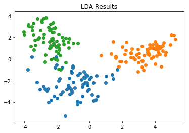

```python
df = pd.read_csv('data/seeds_dataset.txt',sep='\t',header=None)
df.columns = ['Area', 'Perimeter', 'Compactness',
              'Length of kernel', 'Width of kernel', 'Asymmetry coefficient',
             'Length of kernel groove', 'Class']
df = df.sort_values(by=['Class'])
lda = LDA()
lda.fit(X,y)
X_transformed = lda.transform(X)
class1 = df_transformed.iloc[0:70]
class2 = df_transformed.iloc[70:140]
class3 = df_transformed.iloc[140:]

plt.title('LDA Results')
plt.scatter(class1[0], class1[1])
plt.scatter(class2[0], class2[1])
plt.scatter(class3[0], class3[1])

cv_results= cross_validate(lda, X,y,cv=5)
print('LDA Accuracy 5-Fold Results: ')
print(cv_results['test_score'])
```

We now have a strong classification model for predicting seed type that can be visualized in clusters.

## Conclusion

In this case, we tested and compared multiple different classification methods. One note is that we were still able to get decent results despite having a small dataset!